# R Notebook

```r
library(CodeClanData)
```

```r
library(tidyverse)
```

```r
library(janitor)
```

#q1 Take the data in the dataset `qb_revenue_breakdown` and make a stacked bar chart showing the sources of revenue across the two years in the dataset.

```r
qb_revenue_breakdown<- qb_revenue_breakdown
```

```r
names(qb_revenue_breakdown)
```

```
[1] "Product" "Year"    "Revenue"
```

```r
view(qb_revenue_breakdown)
```

```r
head(qb_revenue_breakdown)
```

|  | Product | Year | Revenue |
| --- | --- | --- | --- |
| 1 | Trackers | 2019 | 8994 |
| 2 | Smart Watches | 2019 | 12003 |
| 3 | Accessories | 2019 | 5250 |
| 4 | Subscription Services | 2019 | 3750 |
| 5 | Trackers | 2018 | 8004 |
| 6 | Smart Watches | 2018 | 11000 |

```r
ggplot(qb_revenue_breakdown) +
  geom_bar(aes(x = year, y = Revenue)
```

```
Error: Incomplete expression: ggplot(qb_revenue_breakdown) +
  geom_bar(aes(x = year, y = Revenue)
```

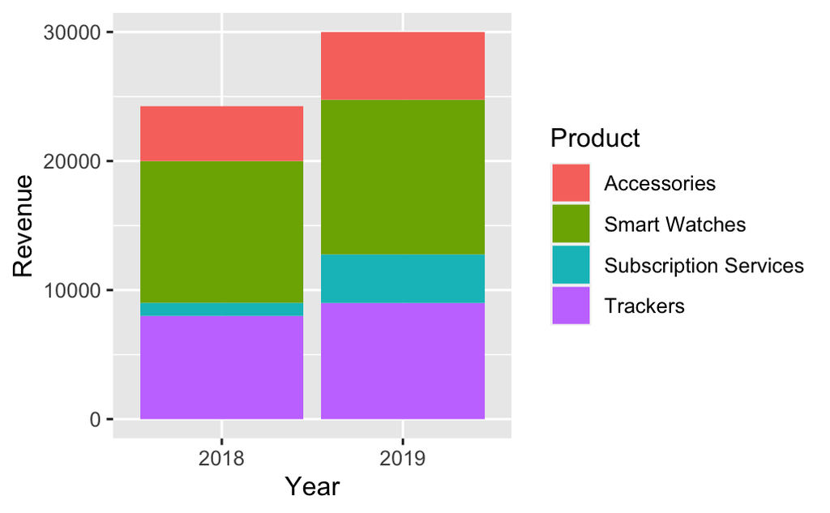

```r
ggplot(qb_revenue_breakdown) +
 geom_col(aes(x = Year, y = Revenue, fill = Product))
```

#q2Make a line chart showing monthly sales of the “flagship product” - the ‘KwikBit Unit 1’ - over the last year. This data is inside `qb_monthly_sales`, but you will need to use `filter()` or `subset()` (base `R)`.

```r
 qb_monthly_sales <-  qb_monthly_sales
```

```r
sales <- qb_monthly_sales
```

```r
head(qb_monthly_sales)
```

|  | Date | Cashflow | Amount |
| --- | --- | --- | --- |
| 1 | 2019-07-01 | Kwikbit Unit 1 Sales | 601.74 |
| 2 | 2019-06-01 | Kwikbit Unit 1 Sales | 567.89 |
| 3 | 2019-05-01 | Kwikbit Unit 1 Sales | 536.00 |
| 4 | 2019-04-01 | Kwikbit Unit 1 Sales | 550.78 |
| 5 | 2019-03-01 | Kwikbit Unit 1 Sales | 526.03 |
| 6 | 2019-02-01 | Kwikbit Unit 1 Sales | 584.22 |

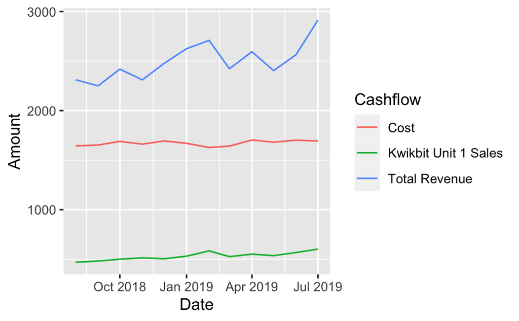

```r
salse <- qb_monthly_sales  %>%
filter(Cashflow == "Kwikbit Unit 1 Sales")


ggplot(sales) +
  geom_line(aes(x = Date, y = Amount,  colour = Cashflow))
```

```r
NA
NA
```

#03 vMake a line chart showing monthly revenue and costs over the last year. This data is also in `qb_monthly_sales`.

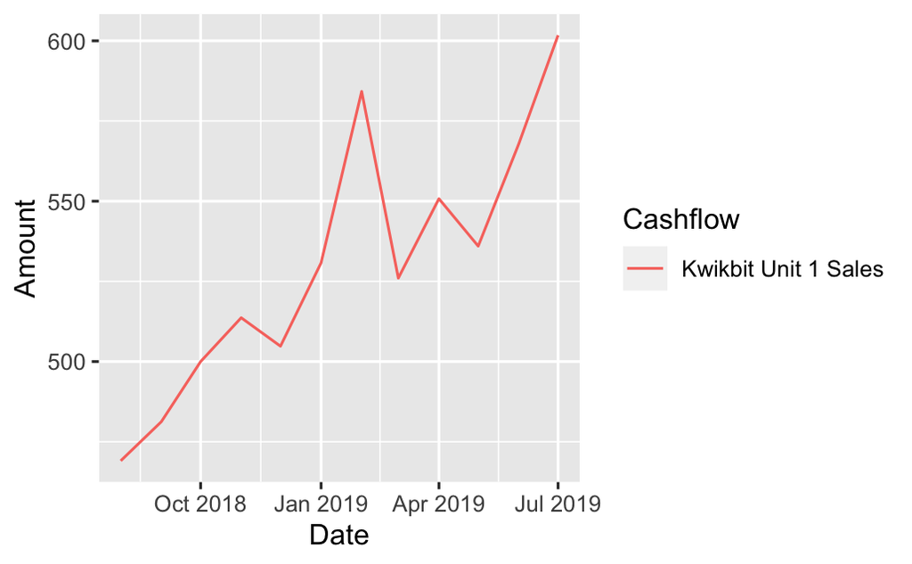

```r
rev_cost_last_year <- qb_monthly_sales %>%
  filter(Cashflow == "Kwikbit Unit 1 Sales")


ggplot(rev_cost_last_year) +
 geom_line(aes(x = Date, y = Amount, colour = Cashflow))
```

#q4 Show annual sales of personal fitness trackers over the last 5 years broken down by company as a ribbon plot (use geom_area). This data is in qb_competitors.

```r
head(qb_competitors)
```

|  | Company | Year | Revenue |
| --- | --- | --- | --- |
| 1 | Competitor 1 | 2019 | 2216000 |
| 2 | Competitor 2 | 2019 | 1760000 |
| 3 | Competitor 3 | 2019 | 1455000 |
| 4 | Competitor 4 | 2019 | 1229000 |
| 5 | Competitor 1 | 2018 | 2144400 |
| 6 | Competitor 2 | 2018 | 1440000 |

```r
qb_competitors<- qb_competitors
```

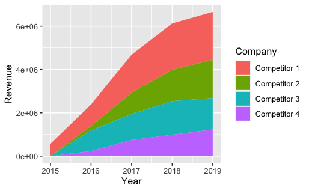

```r
ggplot(qb_competitors) +
  geom_area(aes(x = Year, y = Revenue, fill = Company, position = "dodge"))
```

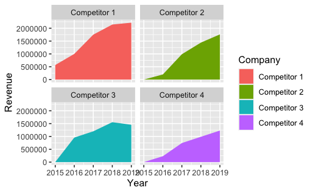

```r
ggplot(qb_competitors) +
  geom_area(aes(x = Year, y = Revenue, fill = Company, position = "dodge"))  +
  facet_wrap(~ Company)
```

#q5Now show the sales from the four competitors as a line graph. Include an extra layer that shows the data points used to make the lines.

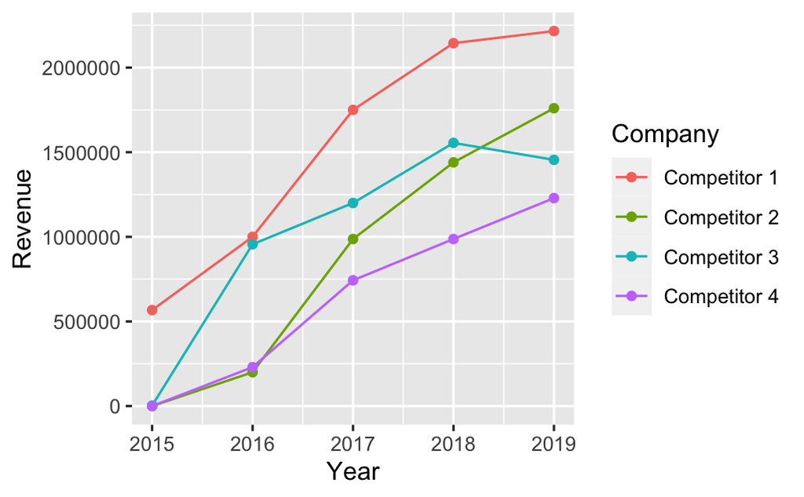

```r
ggplot(qb_competitors) +
 geom_line(aes(x = Year, y = Revenue, colour = Company)) +
  geom_point(aes(x = Year, y = Revenue, colour = Company))
```

```r
NA
NA
```

```r
ggplot(qb_competitors) +
 geom_area(aes(x = Year, y = Revenue, fill = Company, position = "dodge"))
```

[output not shown]

```r
qb_device_data<- qb_device_data
```

```r
ggsave("Kwikbit_sav.pdf")
ggsave("Kwikbit_sav.png")
```